# Homework 3: $K$-Nearest Neighbors

Author

Aayush Shrestha, Anubhav Adhikari, Gerald Akorli

# Introduction

In this homework, you will practice applying the $K$-Nearest Neighbors (KNN) method which is capable of performing both classification and regression. You will also practice collaborating with a team over GitHub.

## Learning goals

By the end of the homework, you will…

- Be able to work simultaneously with teammates on the same document using GitHub
- Fit and interpret KNN models in both regression and classification settings
- Compare and evaluate different KNN models

# Getting Started

In last weeks homework, you learned how to share your work using GitHub but only while working on the same document at different times. This week we will learn how to work on the same document *simultaneously*.

## Teams & Rules

You can find your team for this assignment on Canvas in the **People** section. The group set is called **HW3**. Your group will consist of 2-3 people and has been randomly generated. But first, some rules:

1. You and your team members should be in the same physical room for Exercises 0.1 and 0.2. After that, you are welcome to divide up the work as you see fit. Please note that most of these problems have to be done sequentially except for Exercises 10-12, which can be done apart from 1-9.
2. You are all responsible for understanding the work that you turn in.
3. In order to receive credit, each team member but make a roughly equal contribution. Since this project has 12 exercises (not including 0), each team member should commit and push at least 4 different exercises.
4. If you are working on the same document simultaneously, make sure to render, commit, push, and pull FREQUENTLY.
5. If you encounter a merge error that you don’t know how to fix, contact Dr. Friedlander as soon as possible. I recommend starting this assignment early so there is time for Dr. Friedlander to help you resolve any problems before the deadline.

## Clone the repo & start new RStudio project

The following directions will guide you through the process of setting up your homework to work as a group.

## Exercise 0.1

**Question**

In your group, decide on a team name. Then have **one member of your group**:

1. [Click this link](https://classroom.github.com/a/LEbjScjp) to accept the assignment and enter your team name.
2. Repeat the directions for creating a project from HW 1 with the HW 3 repository.

Once this is complete, the other members can do the same thing, being careful to join the already created team on GitHub classroom.

## Exercise 0.2

We will now learn how to collaborate on the same document at the same time by creating a **merge conflict**. You can read more about it [here](https://happygitwithr.com/pull-tricky#pull-tricky) and [here](https://happygitwithr.com/git-branches.html?q=merge#merging-a-branch).

**Question**

1. Have Members 1, 2, and 3 all create write different team names below and Render the document.
2. Have Member 1 add, commit, and push changes.
3. Have Member 2 add, commit, and push changes. This should cause an error.
4. Have Member 2 pull changes from the remote repo which should generate something like this: `CONFLICT (content): Merge conflict in 03-hw-knn.qmd`.
5. Have Member 2 open the `.qmd` file. You should see something like the third block of code in Section 22.4 of [this link](https://happygitwithr.com/git-branches.html?q=merge#merging-a-branch).
6. Have Member edit the document so that it has only their team name, then render, commit, and push. This should not cause an error.
7. Have Member 3 repeat steps 3-6.
8. Agree on what you want your team name to actually be and have Member 1 repeat steps 3-6.
9. Note that you will only generate a merge conflict if you make edits to the same line of code. If you are working on the same document simultaneously but are editing different portions, git should automatically merge for you.
- Team Name: Linear Depression
- Member 1: Aayush Shrestha
- Member 2: Gerald Akorli
- Member 3: Anubhav Adhikari

# $K$-Nearest Neighbors

The basic idea is that predictions are made based on the $K$ observation in the training data which are “closest” to the observation that we’re making a prediction for. While many different **metrics** (i.e. measures of distance) can be used, we will work exclusively with the **Euclidean metric**:
$$\text{dist}(x, y) = \sqrt{\sum_{i=1}^p(x_i-y_i)^2}$$
for vectors $x = (x_1,\ldots, x_p)$ and $y = (y_1,\ldots,y_p)$.

## KNN for Classification

We’ll start by using KNN for classification.

## Data

We will be working with the famous `iris` data set which consists of four measurements (in centimeters) for 150 plants belonging to three species of iris. This data set was first published in a classic 1936 paper by English statistician, and notable racist/eugenicist, Ronald Fisher. In that paper, multivariate linear models were applied to classify these plants. Of course, back then, model fitting was an extremely laborious process that was done without the aid of calculators or statistical software.

## Exercise 1

**Question**

Import the `datasets` package, take a look at the columns of `iris`, and split your data into training and test sets using a 70-30 split. IMPORTANT: Make sure that each species is represented proportionally in the training set by using the `strata` argument in the `initial_split` function! Once again, set your seed to 427.

```r
library(tidymodels)
library(datasets)

tidymodels_prefer() # Avoid errors
set.seed(427)

# Load and check data
data("iris")
colnames(iris) # View column names
```

```
[1] "Sepal.Length" "Sepal.Width"  "Petal.Length" "Petal.Width"  "Species"
```

```r
summary(iris)
```

```
  Sepal.Length    Sepal.Width     Petal.Length    Petal.Width
 Min.   :4.300   Min.   :2.000   Min.   :1.000   Min.   :0.100
 1st Qu.:5.100   1st Qu.:2.800   1st Qu.:1.600   1st Qu.:0.300
 Median :5.800   Median :3.000   Median :4.350   Median :1.300
 Mean   :5.843   Mean   :3.057   Mean   :3.758   Mean   :1.199
 3rd Qu.:6.400   3rd Qu.:3.300   3rd Qu.:5.100   3rd Qu.:1.800
 Max.   :7.900   Max.   :4.400   Max.   :6.900   Max.   :2.500
       Species
 setosa    :50
 versicolor:50
 virginica :50
```

```r
# Split data
iris_split <- initial_split(iris, prop = 0.7, strata = Species) # initialize 70/30
iris_train <- training(iris_split) # Get training data
iris_test <- testing(iris_split) # Get testing data
```

## Exercise 2

**Question**

Create a scatter plot of your training set with `Sepal.Width` and `Petal.Width` on the x- and y- axes, respectively, and color the points by `Species`.

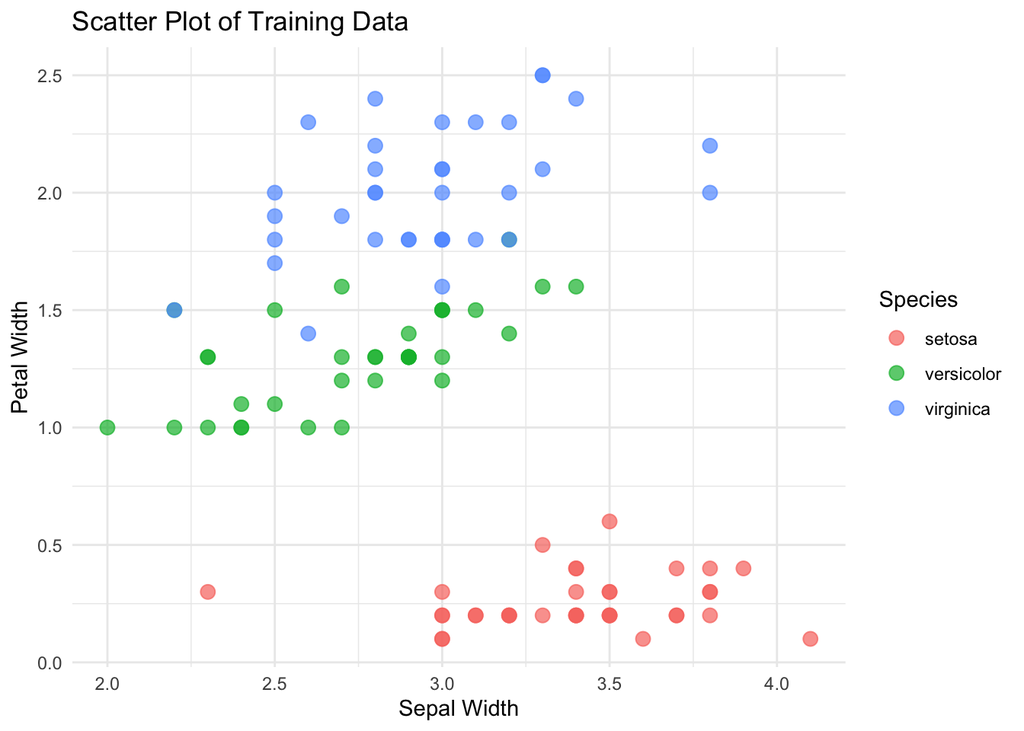

```r
ggplot(iris_train, aes(x = Sepal.Width, y = Petal.Width, color = Species)) +
  geom_point(size = 3, alpha = 0.7) +
  labs(title = "Scatter Plot of Training Data",
       x = "Sepal Width",
       y = "Petal Width",
       color = "Species") +
  theme_minimal()
```

## Exercise 3

**Question**

As the name suggests, the $K$-nearest neighbors (KNN) method classifies a point based on the classification of the observations in the training set that are nearest to that point. If $k > 1$, then the neighbors essentially “vote” on the classification of the point. Using only your graph, if $k = 1$, how would KNN classify a flower that had sepal width 3cm and petal width 1cm?

## Exercise 4

**Question**

Just to verify that we are correct, find the sepal width, petal width, and species of the observation in your training set that is closest to our flower with sepal width 3cm and petal width 1cm. This should be done by computing the Euclidean distance of (3, 1) to each observation and then sorting the resulting tibble to get the row with the smallest distance. Don’t worry about normalizaing the data.

```r
iris_train <- iris_train |>
  mutate(distance = sqrt((Sepal.Width - 3)^2 + (Petal.Width - 1)^2))

closest_observation <- iris_train |> slice(1)
closest_observation
```

```
  Sepal.Length Sepal.Width Petal.Length Petal.Width Species  distance
1          5.1         3.5          1.4         0.2  setosa 0.9433981
```

```r
iris_train <- iris_train %>%
  select(-distance)
```

## Exercise 5

**Question**

Create a `recipe` to center and scale your data sets using the mean and standard deviation from your training set.

```r
iris_recipe <- recipe(Species~ Sepal.Length + Petal.Width, data = iris_train) |>
  step_dummy(all_nominal_predictors()) |>
  step_center(all_numeric_predictors()) |> #Center all predictors
  step_scale(all_numeric_predictors())  #Scale all predictors

iris_prep <- prep(iris_recipe)

iris_prepped <- prep(iris_recipe, training = iris_train) #Computes the means and standard deviations.

iris_train_scaled <- bake(iris_prepped, new_data = iris_train) #Applying the transformations

head(iris_train_scaled)
```

```
# A tibble: 6 × 3
  Sepal.Length Petal.Width Species
         <dbl>       <dbl> <fct>
1       -0.877       -1.32 setosa
2       -1.12        -1.32 setosa
3       -1.37        -1.32 setosa
4       -1.49        -1.32 setosa
5       -0.508       -1.05 setosa
6       -1.49        -1.18 setosa
```

```r
summary(iris_train_scaled)
```

```
  Sepal.Length      Petal.Width            Species
 Min.   :-1.8614   Min.   :-1.4495   setosa    :35
 1st Qu.:-0.8774   1st Qu.:-1.1825   versicolor:35
 Median :-0.1394   Median : 0.1526   virginica :35
 Mean   : 0.0000   Mean   : 0.0000
 3rd Qu.: 0.5986   3rd Qu.: 0.8201
 Max.   : 2.5666   Max.   : 1.7547
```

## Exercise 6

**Question**

Create a `workflow` to fit a KNN model that uses `weight_func = "rectangular"` with 1 neighbor that includes the recipe above and fit the model to your training set.

We would like to understand how the method of $K$-nearest neighbors will classify points in the plane. That is, we would like to view the *decision boundaries* of this model. To do this, we will use our model to classify a large grid of points in the plane, and color them by their classification. The code below creates a data frame called `grid` consisting of 6.25^{4} points in the plane.

```r
# g1 <- rep((200:450)*(1/100), 250)
# g2 <- rep((0:250)*(1/100), each = 250)
# grid <- tibble(  x1 = g1
#                    , x2 = g2)
```

```r
# Define the KNN model with 1 neighbor and rectangular weighting
knn_model <- nearest_neighbor(neighbors = 1, weight_func = "rectangular") |>
  set_engine("kknn") |>
  set_mode("classification")

# Create a workflow
knn_workflow <- workflow() |>
  add_model(knn_model) |>
  add_recipe(iris_recipe)

# Fit the model to the training data
knn_fit <- knn_workflow |>
  fit(data = iris_train)

# Print the fitted model
knn_fit
```

```
══ Workflow [trained] ══════════════════════════════════════════════════════════
Preprocessor: Recipe
Model: nearest_neighbor()

── Preprocessor ────────────────────────────────────────────────────────────────
3 Recipe Steps

• step_dummy()
• step_center()
• step_scale()

── Model ───────────────────────────────────────────────────────────────────────

Call:
kknn::train.kknn(formula = ..y ~ ., data = data, ks = min_rows(1,     data, 5), kernel = ~"rectangular")

Type of response variable: nominal
Minimal misclassification: 0.05714286
Best kernel: rectangular
Best k: 1
```

## Exercise 7

**Question**

Uncomment the code above, and change the variable names so that it will work with your model. Classify the points in `grid` using your training data and $k = 1$. Then, plot the points in `grid` colored by their classification. Make sure your code is written so that the grid points are being centered and scaled before predictions are being made for them.

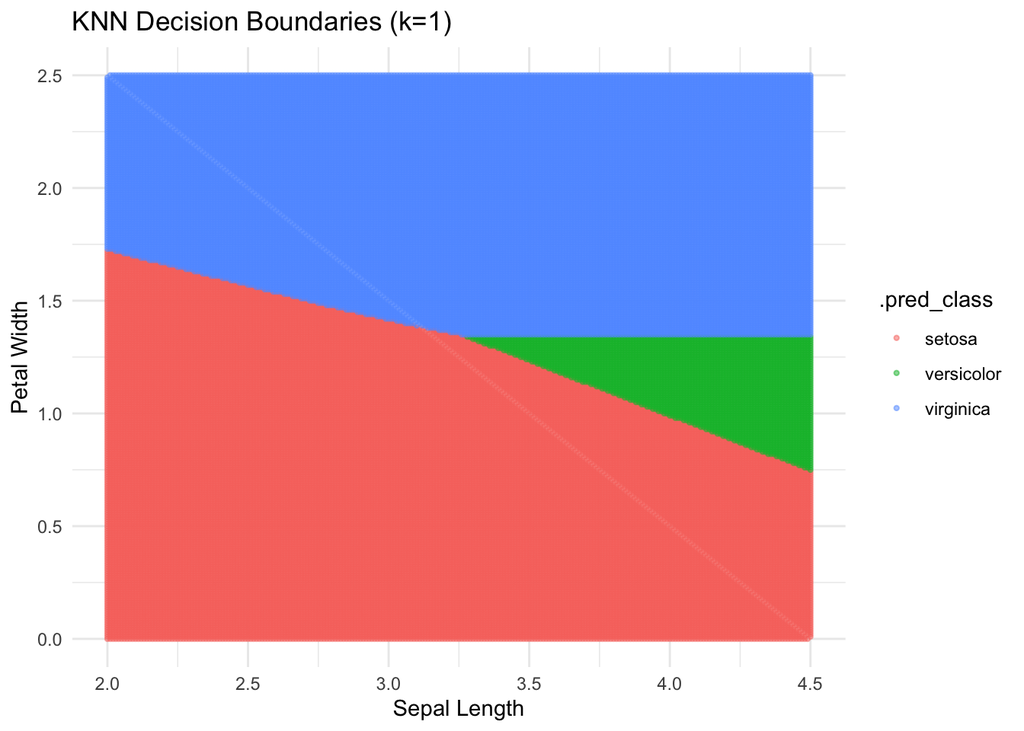

```r
# Generate a grid of points
g1 <- rep((200:450)*(1/100), 250)
g2 <- rep((0:250)*(1/100), each = 250)

grid <- tibble(Sepal.Length = g1, Petal.Width = g2)
# Predict classifications for grid points
grid_predictions <- predict(knn_fit, new_data = grid) |>
  bind_cols(grid)

# Plot decision boundaries
ggplot(grid_predictions, aes(x = Sepal.Length, y = Petal.Width, color = .pred_class)) +
  geom_point(alpha = .5, size = .8) +
  labs(title = "KNN Decision Boundaries (k=1)",
       x = "Sepal Length", y = "Petal Width") +
  theme_minimal()
```

## Exercise 8

**Question**

Notice that the decision boundary between `versicolor` and `virginica` looks a little strange. What do you observe? Why do you think this is happening? Does using $k = 2$ make things better or worse? Why do you think that is?

It is supposed to look odd at k = 2 but KKNN package might break ties differently as opposed to knnreg which was originally used. This might be because k = 2 is choosing one of the two neighbors at random.

## Exercise 9

**Question**

Determine which value of $k$, the number of neighbors selected, gives the highest accuracy on the test set. Test all $k$s between 1 and 40. Note that there may be ties because our data set is a little bit too small. To break ties just choose the smallest $k$ among the ones which are tied. Hint: A for loop may be helpful. What is the accuracy of the model you ended up choosing?

Awesome!! Your model probably did pretty well, because KNN performs really well on the `iris` data set. However, this isn’t a very challenging data set for most classification methods. More challenging data sets have data on different scales and *class imbalance* where there are very few observations belonging to a particular class.

```r
library(tidymodels)
tidymodels_prefer()

# We'll assume you already have:
#   iris_train, iris_test
#   iris_recipe (with step_dummy, step_center, step_scale)
#   etc.

# Define a range of k values:
k_values <- 1:40

# Create a data frame to store results:
results_k <- data.frame(k = k_values, accuracy = NA)

for (i in seq_along(k_values)) {
  # Define the KNN model with k = k_values[i]
  knn_spec_i <- nearest_neighbor(
    mode = "classification",
    neighbors = k_values[i],
    weight_func = "rectangular"
  ) %>%
    set_engine("kknn")

  # Build a workflow using the recipe and model spec:
  knn_wf_i <- workflow() %>%
    add_recipe(iris_recipe) %>%
    add_model(knn_spec_i)

  # Fit on training data:
  knn_fit_i <- fit(knn_wf_i, data = iris_train)

  # Predict on test data:
  preds <- predict(knn_fit_i, new_data = iris_test) %>%
    bind_cols(iris_test)

  # Calculate accuracy:
  acc <- preds %>%
    metrics(truth = Species, estimate = .pred_class) %>%
    filter(.metric == "accuracy") %>%
    pull(.estimate)

  # Store accuracy in results_k:
  results_k$accuracy[i] <- acc
}

# Identify best k:
max_acc <- max(results_k$accuracy)
# In case of ties, pick the smallest k:
best_k <- results_k$k[which(results_k$accuracy == max_acc)][1]

cat("Best k =", best_k, "with accuracy =", max_acc, "\n")
```

```
Best k = 3 with accuracy = 0.9555556
```

# KNN for Regression

For regression, we can predict the response variable for our point to be the average (or sometimes median) of the response variable for the $K$-nearest neighbors.

## Data & Dummy Variables

For this portion of the homework, we’ll use the `Carseat` data from the `ISLR2` package. Frequently, when working with categorical data, you will be required to transform that data into **dummy variables**. Namely, you’ll create a unique variable for each column which gets a 1 if the corresponding observation is from that category and a 0 otherwise. In data science, this format is sometimes referred to as **one-hot encoding**.

## Exercise 10

**Question**

Look at the `Carseat` data from the `ISLR2` package. Then, split the data into a training and test set using a 70-30 split and a seed of 427 (as usual).

```r
library(ISLR2)
data("Carseats")

set.seed(427)
carseat_split <- initial_split(Carseats, prop = 0.7)
carseat_train <- training(carseat_split)
carseat_test  <- testing(carseat_split)

nrow(carseat_train)
```

```
[1] 280
```

```r
nrow(carseat_test)
```

```
[1] 120
```

## Exercise 11

**Question**

Create a recipe which first, converts all categorical variables into dummy variables using `step_dummy()` then centers and scales all of the predictors based on the training data.

```r
carseat_recipe <- recipe(Sales ~ ., data = carseat_train) %>%
  step_dummy(all_nominal_predictors()) %>%
  step_center(all_predictors()) %>%
  step_scale(all_predictors())

carseat_prep <- prep(carseat_recipe)


carseat_train_prepped <- bake(carseat_prep, new_data = NULL)
carseat_test_prepped  <- bake(carseat_prep, new_data = carseat_test)

head(carseat_train_prepped)
```

```
# A tibble: 6 × 12
  CompPrice  Income Advertising Population  Price    Age Education Sales
      <dbl>   <dbl>       <dbl>      <dbl>  <dbl>  <dbl>     <dbl> <dbl>
1    0.0450 -0.227        1.12      1.41   -0.103  1.62     -0.383  8.67
2    1.30    0.0234       1.87      1.57   -0.387 -0.543    -1.16  12.0
3   -0.710  -1.19         0.519     0.0158 -1.40   0.321    -0.771 10.1
4   -0.144   1.20         1.87      1.36    0.342 -1.53     -0.383  8.32
5    0.171  -0.334       -0.978     0.486  -0.629  0.691    -0.771  7.99
6   -0.522  -1.01        -0.978    -1.29   -0.710  1.37      0.392  6.98
# ℹ 4 more variables: ShelveLoc_Good <dbl>, ShelveLoc_Medium <dbl>,
#   Urban_Yes <dbl>, US_Yes <dbl>
```

## Exercise 12

**Question**

Fit a KNN model to predict `Sales` from the data we have. Fit your model on the training data and use the test set to choose the appropriate variables and the number of neighbors to include. You may find it useful to plot the $R^2$ and RMSE against the number of neighbors you include in your model. You may find that the RMSE and $R^2$ disagree on what the best model is. You will have to make a judgement call on which model is “best”. One thing that can be helpful is looking at plots of your target variables (`Sales` in this case) against the model residuals.

```r
# We'll systematically vary k and measure performance:
k_grid <- 1:40

results_reg <- data.frame(k = k_grid, rmse = NA, rsq = NA)

for (i in seq_along(k_grid)) {
  # Define KNN model for regression:
  knn_spec <- nearest_neighbor(
    mode = "regression",
    neighbors = k_grid[i],
    weight_func = "rectangular"
  ) %>%
    set_engine("kknn")

  # Build workflow with the recipe:
  knn_wf <- workflow() %>%
    add_model(knn_spec) %>%
    add_recipe(carseat_recipe)

  # Fit on the original training data:
  knn_fit <- fit(knn_wf, data = carseat_train)

  # Predict on test data:
  preds <- predict(knn_fit, new_data = carseat_test) %>%
    bind_cols(carseat_test)

  # Calculate metrics:
  mets <- preds %>%
    metrics(truth = Sales, estimate = .pred)

  # Extract RMSE and R^2:
  results_reg$rmse[i] <- mets %>% filter(.metric == "rmse") %>% pull(.estimate)
  results_reg$rsq[i]  <- mets %>% filter(.metric == "rsq")  %>% pull(.estimate)
}

# Inspect results:
results_reg
```

```
    k     rmse       rsq
1   1 2.450342 0.3195393
2   2 2.113839 0.4197735
3   3 2.040139 0.4394115
4   4 1.880435 0.5139628
5   5 1.910983 0.4961564
6   6 1.941683 0.4798886
7   7 1.930897 0.4824027
8   8 1.921767 0.4861871
9   9 1.925345 0.4833798
10 10 1.891850 0.5035458
11 11 1.867972 0.5186779
12 12 1.879907 0.5161604
13 13 1.862898 0.5281089
14 14 1.879637 0.5204224
```

[output cut: 26 more lines]

```r
# Find the k that minimizes RMSE:
best_k_rmse <- results_reg$k[which.min(results_reg$rmse)]
best_rmse   <- min(results_reg$rmse)

# Find the k that maximizes R^2:
best_k_rsq  <- results_reg$k[which.max(results_reg$rsq)]
best_rsq    <- max(results_reg$rsq)

cat("Best k by RMSE:", best_k_rmse, "with RMSE =", best_rmse, "\n")
```

```
Best k by RMSE: 13 with RMSE = 1.862898
```

```r
cat("Best k by R^2 :", best_k_rsq,  "with R^2  =", best_rsq,  "\n")
```

```
Best k by R^2 : 39 with R^2  = 0.5734647
```

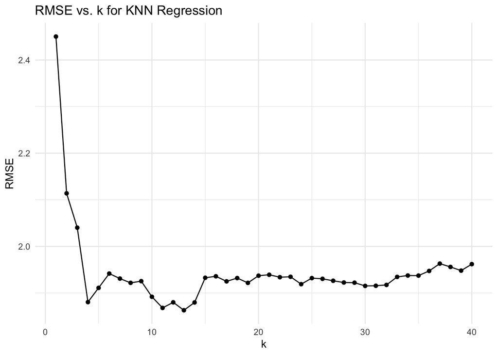

```r
library(ggplot2)

ggplot(results_reg, aes(x = k, y = rmse)) +
  geom_line() + geom_point() +
  labs(title = "RMSE vs. k for KNN Regression", x = "k", y = "RMSE") +
  theme_minimal()
```

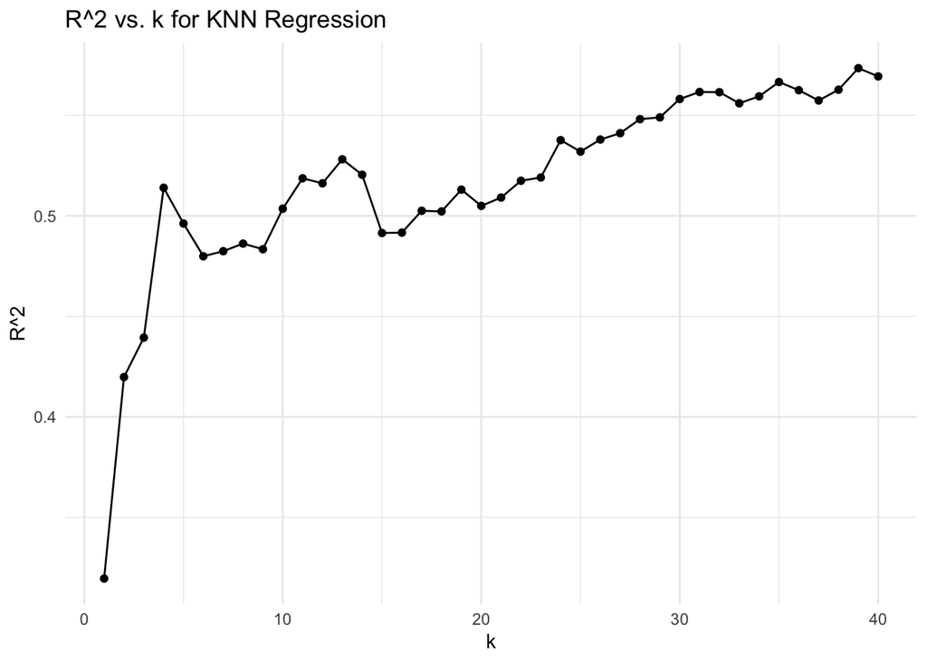

```r
ggplot(results_reg, aes(x = k, y = rsq)) +
  geom_line() + geom_point() +
  labs(title = "R^2 vs. k for KNN Regression", x = "k", y = "R^2") +
  theme_minimal()
```